# DAPC

## 4. Visualization - DAPC

##### **4.a. DAPC by species**

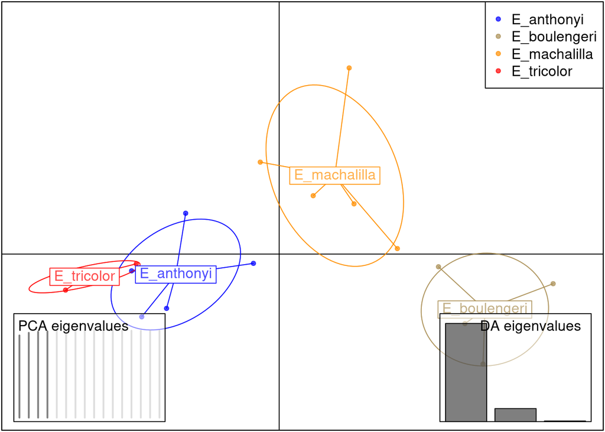

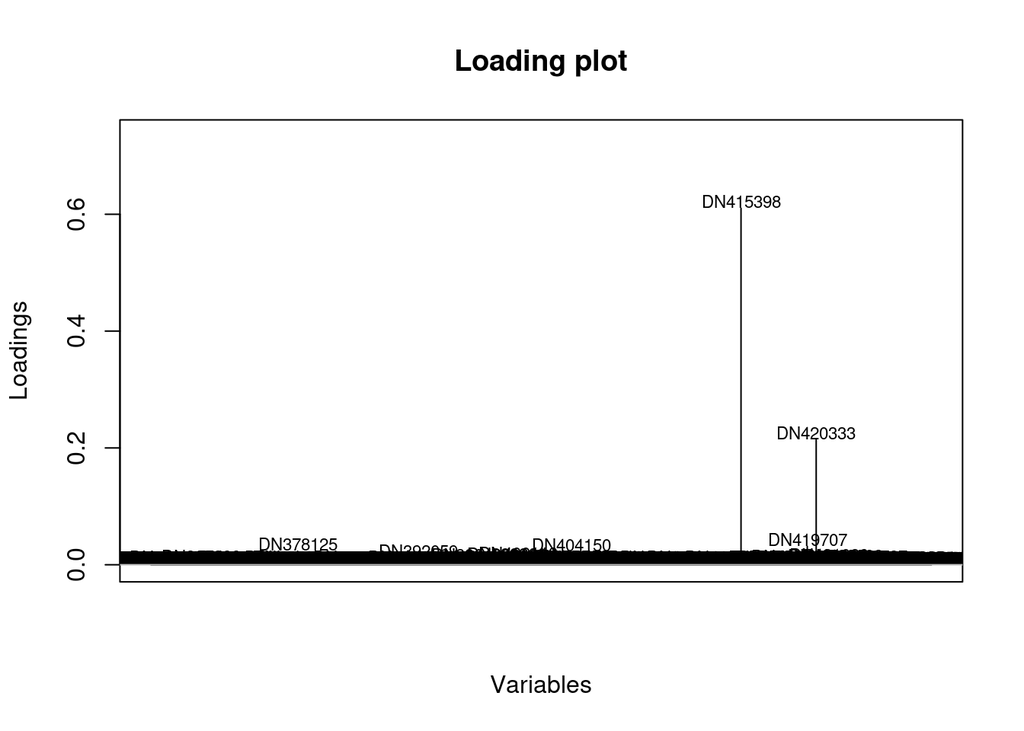

```
## [1] "The proportion of conserved variance is 0.991437635964515"
```

```r
{ # Wrap output (e.g., plots and text) in one chunk using {}
  set.seed(100)

  dapc_species <- dapc(t(normalized_counts_greater_5), PCs_sample$Species,
                       n.pca = 4, n.da = 3)
  scatter.dapc(dapc_species, scree.pca = TRUE, scree.da = TRUE, legend = TRUE)
  loadingplot(dapc_species$var.contr)  # var.contr: A data.frame giving the contributions of
                                       # original variables to the principal components of DAPC
  print(paste("The proportion of conserved variance is", dapc_species$var))
}
```

##### **4.b. DAPC by skin coloration**

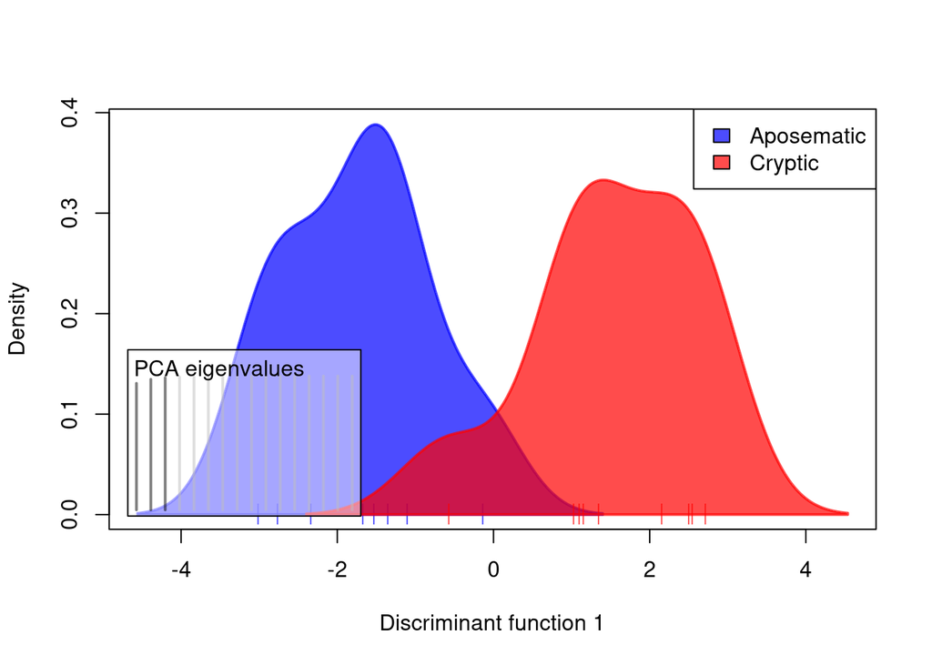

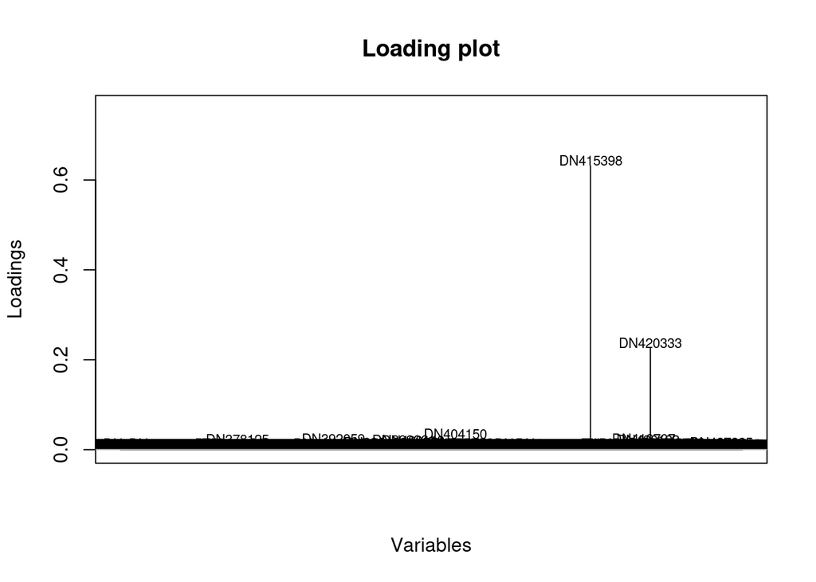

```
## [1] "The proportion of conserved variance is 0.987767357365527"
```

```r
{
  set.seed(100)

  dapc_skin_coloration <- dapc(t(normalized_counts_greater_5), PCs_sample$Skin_Coloration,
                               n.pca = 3, n.da = 1)
  scatter.dapc(dapc_skin_coloration, scree.pca = TRUE, scree.da = TRUE, legend = TRUE)
  loadingplot(dapc_skin_coloration$var.contr)
  print(paste("The proportion of conserved variance is", dapc_skin_coloration$var))
}
```

##### **4.c. DAPC by locality**

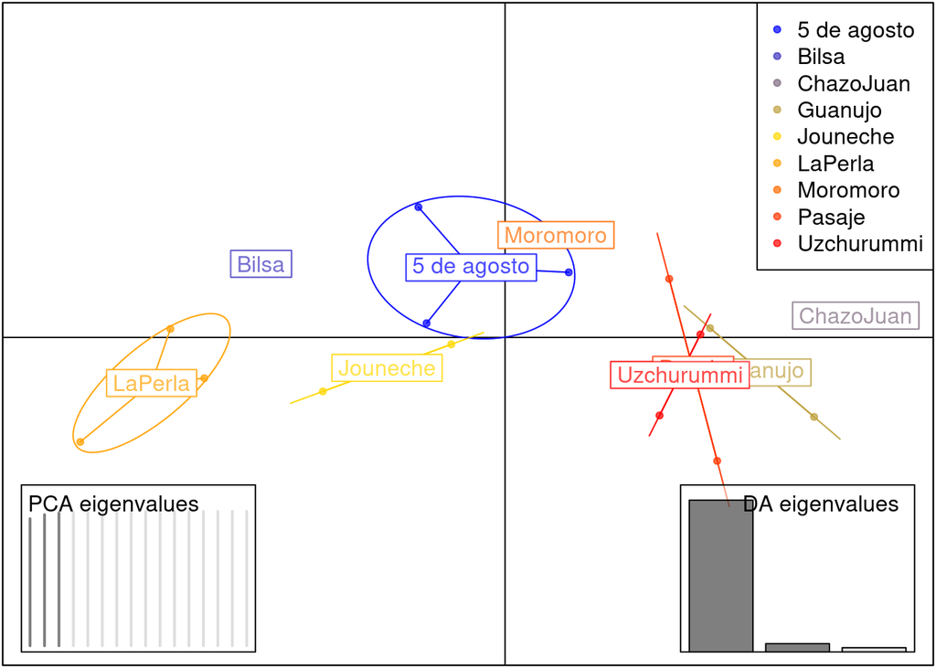

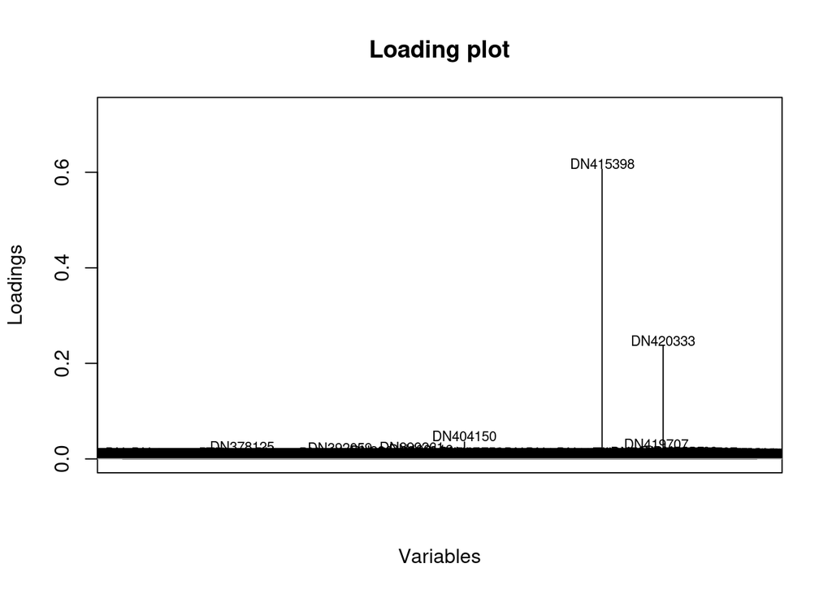

```
## [1] "The proportion of conserved variance is 0.987767357365527"
```

```r
{
  set.seed(100)

  dapc_locality <- dapc(t(normalized_counts_greater_5), PCs_sample$Locality,
                      n.pca = 3, n.da = 18)
  scatter.dapc(dapc_locality, scree.pca = TRUE, scree.da = TRUE, legend = TRUE)
  loadingplot(dapc_locality$var.contr)
  print(paste("The proportion of conserved variance is", dapc_locality$var))
}
```

Same pattern as above

##### **4.d. DAPC by sex**

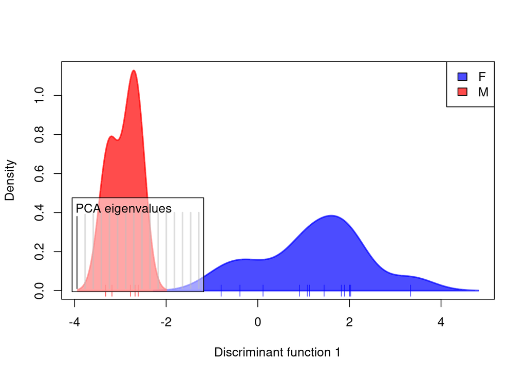

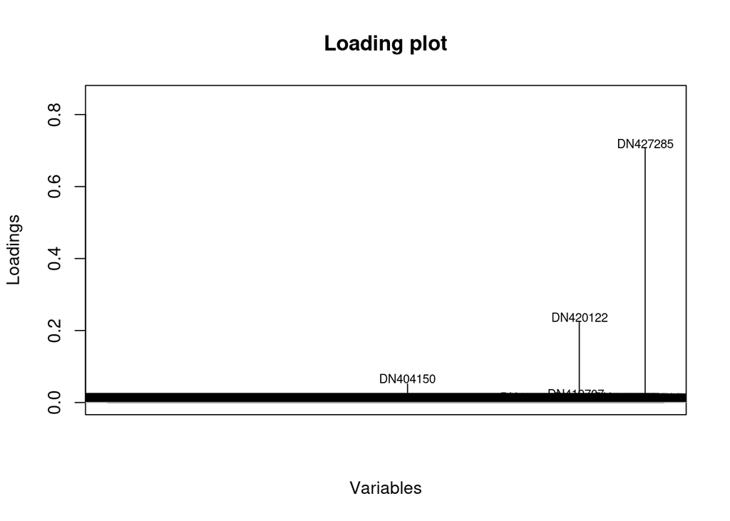

```
## [1] "The proportion of conserved variance is 0.945380078045848"
```

```r
{
  set.seed(100)

  dapc_sex <- dapc(t(normalized_counts_greater_5), PCs_sample$Sex,
                   n.pca = 1, n.da = 1)
  scatter.dapc(dapc_sex, scree.pca = TRUE, scree.da = TRUE, legend = TRUE)
  loadingplot(dapc_sex$var.contr)
  print(paste("The proportion of conserved variance is", dapc_sex$var))
}
```

This time, the separation between male and female is clear and the proportion of conserved variance remains high (although slightly lower than previous ones), the genes responsible for driving the separation are different - DN427285, DN420122, and DN404150. However, DN 427285 doesn’t have a mapping, while both DN420122 (mapping: DROSHA) and DN404150 (mapping: OMP_KIAA0226) are not identified in our DGE or GO analysis

##### **Overall, the genes that primarily drive the difference between the 4 groupings (species, skin coloration, locality, and sex) are either common genes, not found in our DGE or GO analysis (conflicting result), or doesn’t have a mapping. Therefore, it’s not possible to pinpoint any specific gene(s) that results in the separation between Cryptic and Aposematic before further investigations are carried out.**